# GSPP R Tutorial Day 1

# Subsetting dataframes

We can use a dollar sign to extract a single variable (or column) from the dataframe, which will be returned as a vector.

```r
# Display the var1 column from the dataframe.
my_dataframe$var1
```

```
##  [1] 10  9  8  7  6  5  4  3  2  1
```

```r
# Save var1 to a separate vector.
var1_vec = my_dataframe$var1
var1_vec
```

```
##  [1] 10  9  8  7  6  5  4  3  2  1
```

Because the `$` returns a vector, we can tack on brackets to pull out certain elements just like we did earlier.

```r
# Select only the 3rd and 4th elements from the var3 vector.
my_dataframe$var3[3:4]
```

```
## [1] -1.539950 -0.928567
```

We can use brackets on the original dataframe to select certain rows and certain variables at the same time. When we use the brackets we first specify which rows we want, then which columns.

Let’s do the same operation again, but this time without the `$`.

```r
# Return observations 3 and 4, and just the variable "var3".
my_dataframe[3:4, "var3"]
```

```
## [1] -1.539950 -0.928567
```

To return multiple variables we use `c()` when selecting the columns we want.

```r
my_dataframe[3:4, c("var1", "var3")]
```

```
##   var1      var3
## 3    8 -1.539950
## 4    7 -0.928567
```

If we select multiple variables we get a dataframe back rather than a vector.

If we don’t specify which rows we want, R will return all rows.

```r
my_dataframe[, "var3"]
```

```
##  [1]  1.272429321  0.414641434 -1.539950042 -0.928567035 -0.294720447
##  [6] -0.005767173  2.404653389  0.763593461 -0.799009249 -1.147657009
```

Similarly, if we don’t specify which columns we want, R will return all of the variables for those observations.

```r
my_dataframe[9:10, ]
```

```
##    var1 var2       var3
## 9     2    A -0.7990092
## 10    1    B -1.1476570
```

```r
# If you forget the comma you will get an error:
my_dataframe[9:10]
```

```
## Error in `[.data.frame`(my_dataframe, 9:10): undefined columns selected
```

If we don’t specify either then we just get the original dataframe.

```r
my_dataframe[, ]
```

```
##    var1 var2         var3
## 1    10    A  1.272429321
## 2     9    B  0.414641434
## 3     8    A -1.539950042
## 4     7    B -0.928567035
## 5     6    A -0.294720447
## 6     5    B -0.005767173
## 7     4    A  2.404653389
## 8     3    B  0.763593461
## 9     2    A -0.799009249
## 10    1    B -1.147657009
```

```r
my_dataframe[]
```

```
##    var1 var2         var3
## 1    10    A  1.272429321
## 2     9    B  0.414641434
## 3     8    A -1.539950042
## 4     7    B -0.928567035
## 5     6    A -0.294720447
## 6     5    B -0.005767173
## 7     4    A  2.404653389
## 8     3    B  0.763593461
## 9     2    A -0.799009249
## 10    1    B -1.147657009
```

We can “remove” rows by extracting a part of the dataframe that excludes those rows and then re-saving it to the original dataframe.

```r
# Let's look at observations 4 and 8
my_dataframe[c(4, 8), ]
```

```
##   var1 var2       var3
## 4    7    B -0.9285670
## 8    3    B  0.7635935
```

```r
# Now let's exclude those observations and re-assign the data frame.
my_dataframe <- my_dataframe[-c(4, 8), ]

my_dataframe
```

```
##    var1 var2         var3
## 1    10    A  1.272429321
## 2     9    B  0.414641434
## 3     8    A -1.539950042
## 5     6    A -0.294720447
## 6     5    B -0.005767173
## 7     4    A  2.404653389
## 9     2    A -0.799009249
## 10    1    B -1.147657009
```

We can use `subset` to check multiple columns and return the result. It saves a little typing because we don’t have to specify the dataframe each time.

```r
my_dataframe
```

```
##    var1 var2         var3
## 1    10    A  1.272429321
## 2     9    B  0.414641434
## 3     8    A -1.539950042
## 5     6    A -0.294720447
## 6     5    B -0.005767173
## 7     4    A  2.404653389
## 9     2    A -0.799009249
## 10    1    B -1.147657009
```

```r
# Normally we would need to use $, but with the subset function we don't.
subset(my_dataframe, var2 == "A" & var1 > 5)
```

```
##   var1 var2       var3
## 1   10    A  1.2724293
## 3    8    A -1.5399500
## 5    6    A -0.2947204
```

Now let’s look at var2.

```r
my_dataframe$var2
```

```
## [1] A B A A B A A B
## Levels: A B
```

```r
var2
```

```
##  [1] "A" "B" "A" "B" "A" "B" "A" "B" "A" "B"
```

**Class Question**: does anyone know why it shows us “levels” A B?

When we create a dataframe with a character string vector, R converts it to a factor automatically. A factor is a set of numeric codes that correspond to string values. (R does this because it allows for faster computations and requires less computer memory.)

If we want to convert it back to a character string, we can use `as.character()`.

```r
# Display var2 as a string rather than factor.
as.character(my_dataframe$var2)
```

```
## [1] "A" "B" "A" "A" "B" "A" "A" "B"
```

```r
var2
```

```
##  [1] "A" "B" "A" "B" "A" "B" "A" "B" "A" "B"
```

```r
# Save the result to a new column in the dataframe.
# Alternatively we could overwrite the existing column.
my_dataframe$var2_str = as.character(my_dataframe$var2)

my_dataframe
```

```
##    var1 var2         var3 var2_str
## 1    10    A  1.272429321        A
## 2     9    B  0.414641434        B
## 3     8    A -1.539950042        A
## 5     6    A -0.294720447        A
## 6     5    B -0.005767173        B
## 7     4    A  2.404653389        A
## 9     2    A -0.799009249        A
## 10    1    B -1.147657009        B
```

We used the `$` operator to create a new column (variable) and set it to the string version of var2.

If we want to double-check the type of each variable, we use the `class` function.

```r
class(my_dataframe$var1)
```

```
## [1] "integer"
```

```r
class(my_dataframe$var2)
```

```
## [1] "factor"
```

```r
class(my_dataframe$var3)
```

```
## [1] "numeric"
```

```r
class(my_dataframe$var2_str)
```

```
## [1] "character"
```

We can even run `class` on the dataframe.

```r
class(my_dataframe)
```

```
## [1] "data.frame"
```

Or `str` can tell us the class for each variable in the dataframe and show some example values of each variable.

```r
str(my_dataframe)
```

```
## 'data.frame':    8 obs. of  4 variables:
##  $ var1    : int  10 9 8 6 5 4 2 1
##  $ var2    : Factor w/ 2 levels "A","B": 1 2 1 1 2 1 1 2
##  $ var3    : num  1.27243 0.41464 -1.53995 -0.29472 -0.00577 ...
##  $ var2_str: chr  "A" "B" "A" "A" ...
```

# Basic data analysis

We learned `summary` but how can we learn more about a categorical variable? `table` shows us the frequency distribution of the variable.

```r
table(my_dataframe$var1)
```

```
##
##  1  2  4  5  6  8  9 10
##  1  1  1  1  1  1  1  1
```

```r
table(my_dataframe$var2)
```

```
##
## A B
## 5 3
```

```r
table(my_dataframe$var3)   # Not great for continuous variables.
```

```
##
##    -1.53995004190371    -1.14765700923635   -0.799009248989368
##                    1                    1                    1
##    -0.29472044679056 -0.00576717274753696    0.414641434456408
##                    1                    1                    1
##      1.2724293214294     2.40465338885795
##                    1                    1
```

If we also use `prop.table` we can get percentages instead of counts.

```r
prop.table(table(my_dataframe$var2))
```

```
##
##     A     B
## 0.625 0.375
```

We can use table with two variables to generate a cross-tabulation.

```r
table(my_dataframe$var1, my_dataframe$var2)
```

```
##
##      A B
##   1  0 1
##   2  1 0
##   4  1 0
##   5  0 1
##   6  1 0
##   8  1 0
##   9  0 1
##   10 1 0
```

```r
prop.table(table(my_dataframe$var1, my_dataframe$var2))
```

```
##
##          A     B
##   1  0.000 0.125
##   2  0.125 0.000
##   4  0.125 0.000
##   5  0.000 0.125
##   6  0.125 0.000
##   8  0.125 0.000
##   9  0.000 0.125
##   10 0.125 0.000
```

```r
# We can label the rows and columns if we wish.
table("rows" = my_dataframe$var1, "cols" = my_dataframe$var2)
```

```
##     cols
## rows A B
##   1  0 1
##   2  1 0
##   4  1 0
##   5  0 1
##   6  1 0
##   8  1 0
##   9  0 1
##   10 1 0
```

Finally, let’s do a quick histogram of our continuous variable.

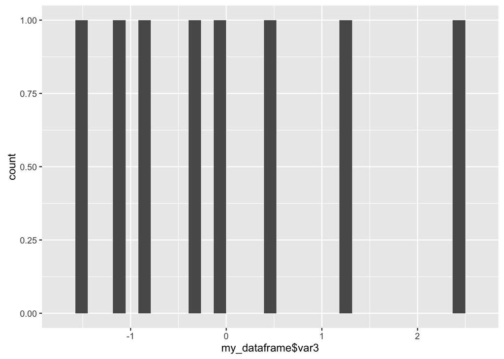

```r
library(ggplot2)
qplot(my_dataframe$var3)
```

# Importing data

We can use the `haven` package to import data from Stata, SPSS, or SAS (good idea Avi).

First, we want to install it using `install.packages`:

```r
install.packages("haven")
```

If you forget the quotes, R will look for a variable called “haven”.

```r
install.packages(haven)
```

```
## Error in install.packages(haven): object 'haven' not found
```

After installing a package, use `library` to load it. Quotes are optional.

```r
library(haven)
library("haven")  # Either way is fine.
```

**Class Question**: How can we figure out what functions haven provides?

To get help on a package, we can’t use `?` or `help` in exactly the same way.

```r
?haven
```

```
## No documentation for 'haven' in specified packages and libraries:
## you could try '??haven'
```

```r
help(haven)
```

```
## No documentation for 'haven' in specified packages and libraries:
## you could try '??haven'
```

```r
??haven
```

Instead we need to specify that we’re looking for a package.

```r
help(package=haven)
```

We can use read_dta to import a Stata file on our computer or the web.

```r
data = read_dta("http://www.ats.ucla.edu/stat/stata/examples/chp/p150.dta")
class(data)     # Notice that it is a dataframe as well as two other classes.
```

```
## [1] "tbl_df"     "tbl"        "data.frame"
```

```r
names(data)
```

```
## [1] "year" "v"    "i"    "d"    "w"    "g"    "p"    "n"
```

```r
dim(data)
```

```
## [1] 21  8
```

```r
summary(data)
```

```
##       year            v                i                  d
##  Min.   :1916   Min.   :0.3612   Min.   :-1.00000   Min.   :-1.00000
##  1st Qu.:1936   1st Qu.:0.4224   1st Qu.:-1.00000   1st Qu.:-1.00000
##  Median :1956   Median :0.5009   Median : 1.00000   Median : 0.00000
##  Mean   :1956   Mean   :0.4907   Mean   : 0.04762   Mean   : 0.09524
##  3rd Qu.:1976   3rd Qu.:0.5377   3rd Qu.: 1.00000   3rd Qu.: 1.00000
##  Max.   :1996   Max.   :0.6246   Max.   : 1.00000   Max.   : 1.00000
##        w                g                 p                n
##  Min.   :0.0000   Min.   :-14.901   Min.   : 0.028   Min.   : 1.000
##  1st Qu.:0.0000   1st Qu.:  0.114   1st Qu.: 2.268   1st Qu.: 4.000
##  Median :0.0000   Median :  2.293   Median : 3.692   Median : 5.000
##  Mean   :0.1429   Mean   :  1.245   Mean   : 4.560   Mean   : 6.095
##  3rd Qu.:0.0000   3rd Qu.:  4.623   3rd Qu.: 5.678   3rd Qu.: 7.000
##  Max.   :1.0000   Max.   : 11.921   Max.   :16.535   Max.   :14.000
```

To import data from our computer, we would want to know what folder R is running from - our working directory.

```r
getwd()
```

```
## [1] "/Users/chrisken/Dropbox/Berkeley/trainings/r-intro-2016"
```

If we put the .dta file into that directory, then we can load it by just specifying the file name.

```r
# R will look for example.dta in the folder displayed by getwd().
data = read_dta("example.dta")
```

If the file is in another directory, we will need to tell R exactly where to look.

```r
data <- read_dta("/Users/username/Downloads/downloaded_file.dta")
```

If we have a CSV or tab-delimited file, we can use the readr package.

```r
install.packages("readr")
```

```r
library(readr)
# Read a tab-delimited file - this one on educational expenditures.
data = read_tsv("http://www.ats.ucla.edu/stat/examples/chp/p189.txt")
# Use read_csv for CSV files.
```

# Questions / Review / Additional Dataset Exercises

That’s all for today, well done!